# Assignment-7 Indian Statistical Inst-Hyderabad

Certification program on Business Analytics

Mallesham Yamulla

## Introduction to Linear Regression

*The below given necessary R packages have been made use of to build up statistical models*

```r
library(tidyverse)
library(caret)
library(broom)
library(yardstick)
library(mosaic)
```

### Glace at datasets

```r
# Unemployement Dataset

knitr::kable(head(paro_isi))
```

| male_unemployment | female_unemployment |
| --- | --- |
| 2.9 | 4.0 |
| 6.7 | 7.4 |
| 4.9 | 5.0 |
| 7.9 | 7.2 |
| 9.8 | 7.9 |
| 6.9 | 6.1 |

```r
# BloodPressure Dataset

knitr::kable(head(bloodpressure_isi))
```

| blood_pressure | age | weight |
| --- | --- | --- |
| 132 | 52 | 173 |
| 143 | 59 | 184 |
| 153 | 67 | 194 |
| 162 | 73 | 211 |
| 154 | 64 | 196 |
| 168 | 74 | 220 |

```r
# Sparrow Dataset

knitr::kable(head(sparrow_isi))
```

| status | age | total_length | wingspan | weight | beak_head | humerus | femur | legbone | skull | sternum |
| --- | --- | --- | --- | --- | --- | --- | --- | --- | --- | --- |
| Survived | adult | 154 | 241 | 24.5 | 31.2 | 0.69 | 0.67 | 1.02 | 0.59 | 0.83 |
| Survived | adult | 160 | 252 | 26.9 | 30.8 | 0.74 | 0.71 | 1.18 | 0.60 | 0.84 |
| Survived | adult | 155 | 243 | 26.9 | 30.6 | 0.73 | 0.70 | 1.15 | 0.60 | 0.85 |
| Survived | adult | 154 | 245 | 24.3 | 31.7 | 0.74 | 0.69 | 1.15 | 0.58 | 0.84 |
| Survived | adult | 156 | 247 | 24.1 | 31.5 | 0.71 | 0.71 | 1.13 | 0.57 | 0.82 |
| Survived | adult | 161 | 253 | 26.5 | 31.8 | 0.78 | 0.74 | 1.14 | 0.61 | 0.89 |

```r
# Houses datasets

knitr::kable(head(houses_isi))
```

| size | price |
| --- | --- |
| 72 | 156 |
| 98 | 153 |
| 92 | 230 |
| 90 | 152 |
| 44 | 42 |
| 46 | 157 |

```r
# Runners Dataset

knitr::kable(head(runners_isi))
```

| X | age | net | gun | sex | year | nruns | runs_again |
| --- | --- | --- | --- | --- | --- | --- | --- |
| 3 | 33 | NA | 92.40 | M | 2007 | 4 | TRUE |
| 7 | 30 | 82.37 | 85.70 | M | 2006 | 3 | FALSE |
| 10 | 29 | 69.32 | 69.68 | M | 2004 | 4 | TRUE |
| 14 | 28 | 79.70 | 80.42 | M | 2002 | 8 | TRUE |
| 22 | 33 | NA | 105.40 | F | 2008 | 3 | FALSE |
| 25 | 32 | 111.80 | 121.20 | M | 2006 | 3 | FALSE |

```r
# Runners Second Dataset

knitr::kable(head(runnerscmp_isi))
```

| age | net | gun | sex | year | previous | nruns | start_position | orig.id |
| --- | --- | --- | --- | --- | --- | --- | --- | --- |
| 54 | 90.00 | 90.28 | F | 2004 | 5 | 9 | eager | 5035 |
| 27 | 74.22 | 75.08 | M | 2001 | 1 | 8 | eager | 10 |
| 24 | 90.85 | 93.55 | F | 2000 | 0 | 4 | calm | 9271 |
| 39 | 91.70 | 95.18 | F | 2004 | 1 | 3 | mellow | 256 |
| 52 | 94.13 | 99.40 | M | 2005 | 1 | 4 | mellow | 1175 |
| 28 | 99.13 | 105.60 | M | 2003 | 1 | 5 | mellow | 17334 |

### CASE 0 : Build a simple linear regression on Unemployement data

```r
# Fitting a model

paro_lm <- lm(female_unemployment ~ male_unemployment, data=paro_isi)

# Model summary

knitr::kable (paro_lm %>% tidy())
```

| term | estimate | std.error | statistic | p.value |
| --- | --- | --- | --- | --- |
| (Intercept) | 1.4341108 | 0.6033982 | 2.376724 | 0.0367131 |
| male_unemployment | 0.6945292 | 0.0976748 | 7.110632 | 0.0000197 |

```r
paro_aug <- paro_lm %>% augment()

knitr::kable(head(paro_aug))
```

| female_unemployment | male_unemployment | .fitted | .se.fit | .resid | .hat | .sigma | .cooksd | .std.resid |
| --- | --- | --- | --- | --- | --- | --- | --- | --- |
| 4.0 | 2.9 | 3.448246 | 0.3389296 | 0.5517545 | 0.3411726 | 0.5693532 | 0.3553431 | 1.1714876 |
| 7.4 | 6.7 | 6.087456 | 0.1766682 | 1.3125439 | 0.0926983 | 0.4248445 | 0.2880855 | 2.3747375 |
| 5.0 | 4.9 | 4.837304 | 0.1910381 | 0.1626961 | 0.1083914 | 0.6061374 | 0.0053595 | 0.2969393 |
| 7.2 | 7.9 | 6.920891 | 0.2490670 | 0.2791083 | 0.1842415 | 0.6006844 | 0.0320284 | 0.5325614 |
| 7.9 | 9.8 | 8.240497 | 0.4086926 | -0.3404969 | 0.4960767 | 0.5893762 | 0.3363347 | -0.8266251 |
| 6.1 | 6.9 | 6.226362 | 0.1855820 | -0.1263624 | 0.1022886 | 0.6071184 | 0.0030096 | -0.2298407 |

```r
knitr::kable(glance(paro_lm))
```

| r.squared | adj.r.squared | sigma | statistic | p.value | df | logLik | AIC | BIC | deviance | df.residual |
| --- | --- | --- | --- | --- | --- | --- | --- | --- | --- | --- |
| 0.8213157 | 0.8050716 | 0.5802596 | 50.56108 | 1.97e-05 | 2 | -10.28471 | 26.56943 | 28.26428 | 3.703714 | 11 |

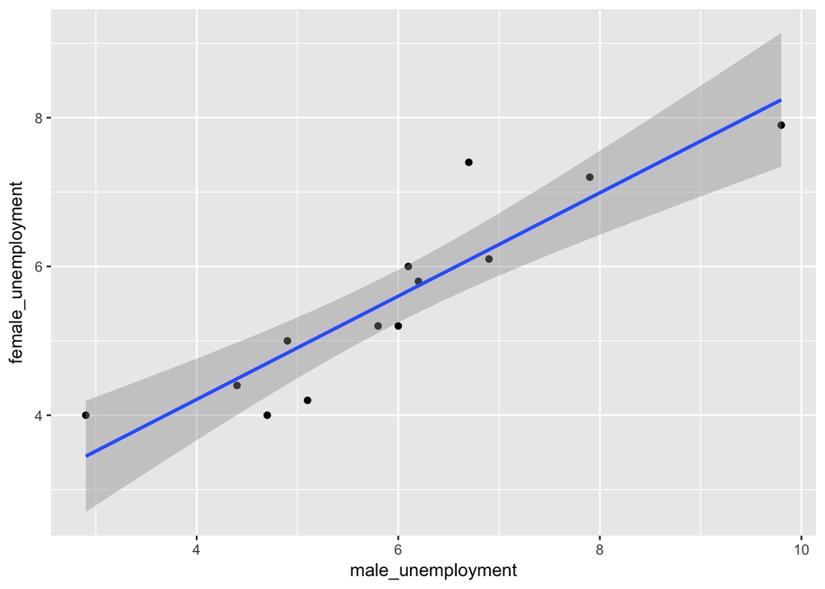

```r
# Visualization

ggplot(paro_isi,aes(male_unemployment,female_unemployment)) + geom_point() + geom_smooth(method = "lm")
```

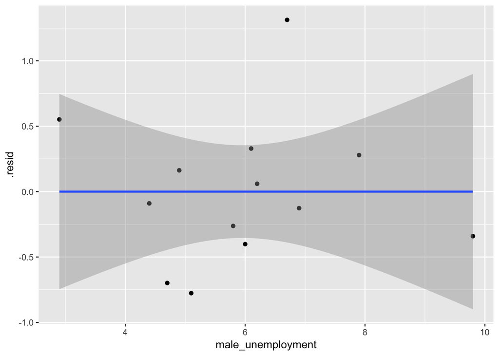

```r
# Residual Analysis

ggplot(paro_aug,aes(male_unemployment,.resid)) + geom_point() + geom_smooth(method = "lm")
```

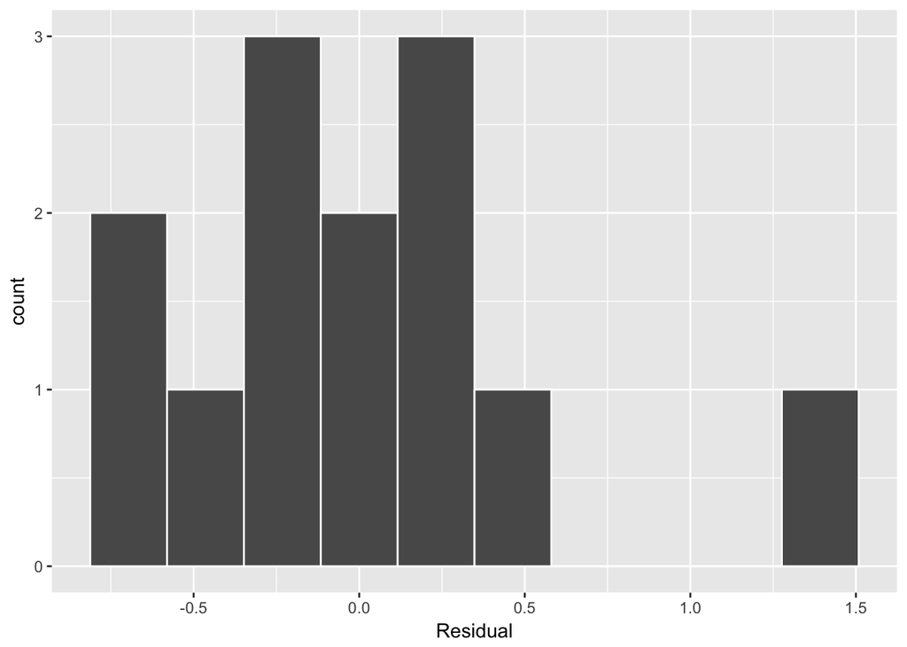

```r
ggplot(paro_aug, aes(x = .resid)) + geom_histogram(color = "white", bins = 10) + labs(x = "Residual")
```

> The male unemployment appears to be highly significant. The $R^2$ suggests that the model explains 82% of the variability of the response variable ‘female_unemployment’

> .

$$Y= \beta_0 + \beta_1 * X$$

$$femaleunemployment= 1.434 + 0.694 * maleunemployement$$

> From the equation we can conclude that there is an expected increase of 0.69 percent of female unemployement for every 1 unit of increase in male unemployment

### CASE 1 : Build a simple linear regression on House Data

```r
# Fitting a model

houses_lm <- lm(price ~ size, data=houses_isi)

# Summarizing model

knitr::kable(houses_lm %>% tidy())
```

| term | estimate | std.error | statistic | p.value |
| --- | --- | --- | --- | --- |
| (Intercept) | -124.722668 | 37.3657829 | -3.337884 | 0.0018982 |
| size | 3.965511 | 0.3787094 | 10.471117 | 0.0000000 |

```r
houses_aug <- houses_lm %>% augment()

knitr::kable(head(houses_aug))
```

| price | size | .fitted | .se.fit | .resid | .hat | .sigma | .cooksd | .std.resid |
| --- | --- | --- | --- | --- | --- | --- | --- | --- |
| 156 | 72 | 160.79411 | 13.86201 | -4.794109 | 0.0397562 | 70.45086 | 0.0001025 | -0.0703710 |
| 153 | 98 | 263.89739 | 11.08138 | -110.897390 | 0.0254062 | 67.99206 | 0.0340297 | -1.6157936 |
| 230 | 92 | 240.10433 | 11.02688 | -10.104325 | 0.0251570 | 70.43536 | 0.0002796 | -0.1472029 |
| 152 | 90 | 232.17330 | 11.11240 | -80.173304 | 0.0255487 | 69.17870 | 0.0178908 | -1.1682238 |
| 42 | 44 | 49.75981 | 21.99321 | -7.759807 | 0.1000760 | 70.44261 | 0.0007697 | -0.1176588 |
| 157 | 46 | 57.69083 | 21.34054 | 99.309171 | 0.0942244 | 68.33515 | 0.1171719 | 1.5009126 |

```r
knitr::kable(glance(houses_lm))
```

| r.squared | adj.r.squared | sigma | statistic | p.value | df | logLik | AIC | BIC | deviance | df.residual |
| --- | --- | --- | --- | --- | --- | --- | --- | --- | --- | --- |
| 0.7426247 | 0.7358516 | 69.52222 | 109.6443 | 0 | 2 | -225.3975 | 456.7951 | 461.8617 | 183666.9 | 38 |

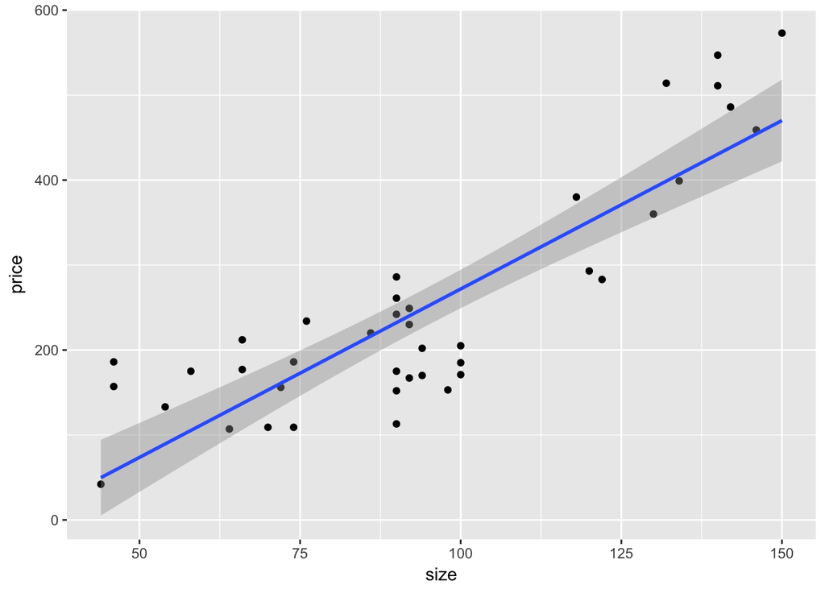

```r
# Visualization

ggplot(houses_isi,aes(size,price)) + geom_point() + geom_smooth(method = "lm")
```

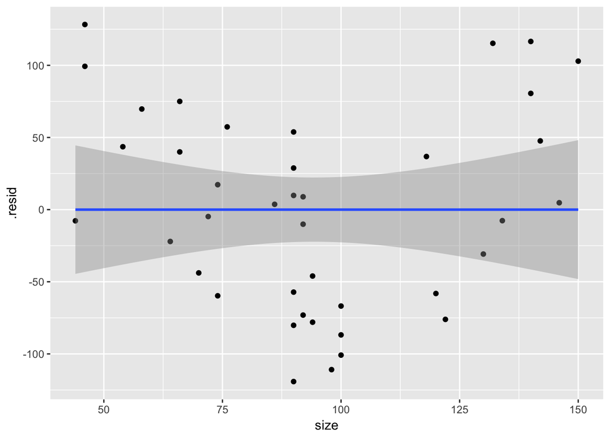

```r
# Residual Analysis

ggplot(houses_aug,aes(size,.resid)) + geom_point() + geom_smooth(method = "lm")
```

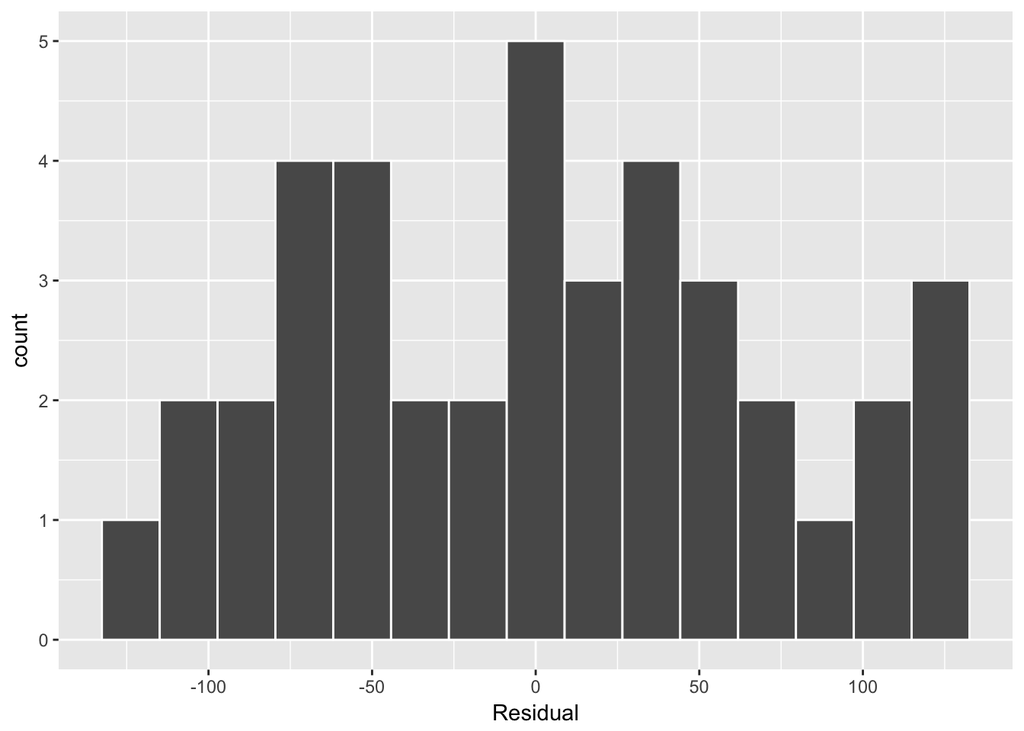

```r
ggplot(houses_aug, aes(x = .resid)) + geom_histogram(color = "white", bins = 15) + labs(x = "Residual")
```

> The size of a home appears to be highly significant. The $R^2$ suggests that the model explains 74% of the variability of the response variable ‘price’

> .

$$price= -124.72 + 3.96 * size$$

> From the equation we can say that there is an expected increase of 3.96 percent of price of a home for every 1 unit of increase in house size

### CASE 2 : Build a multiple linear regression on BloodPressure

```r
# Fitting a model

bloodpressure_lm <- lm(blood_pressure ~ age + weight, data=bloodpressure_isi)

# Summarizing a model

knitr::kable(bloodpressure_lm %>% tidy())
```

| term | estimate | std.error | statistic | p.value |
| --- | --- | --- | --- | --- |
| (Intercept) | 30.9941030 | 11.9437804 | 2.594999 | 0.0318645 |
| age | 0.8614147 | 0.2482314 | 3.470208 | 0.0084402 |
| weight | 0.3348592 | 0.1306683 | 2.562666 | 0.0335077 |

```r
bloodpressure_aug <-  bloodpressure_lm %>% augment()

knitr::kable(head(bloodpressure_aug))
```

| blood_pressure | age | weight | .fitted | .se.fit | .resid | .hat | .sigma | .cooksd | .std.resid |
| --- | --- | --- | --- | --- | --- | --- | --- | --- | --- |
| 132 | 52 | 173 | 133.7183 | 1.1711737 | -1.7183078 | 0.2552329 | 2.361246 | 0.0842695 | -0.8588903 |
| 143 | 59 | 184 | 143.4317 | 0.9786426 | -0.4316617 | 0.1782142 | 2.471728 | 0.0030499 | -0.2054051 |
| 153 | 67 | 194 | 153.6716 | 1.4344720 | -0.6715712 | 0.3828937 | 2.457117 | 0.0281265 | -0.3687730 |
| 162 | 73 | 211 | 164.5327 | 1.1648211 | -2.5326657 | 0.2524716 | 2.217206 | 0.1797569 | -1.2636041 |
| 154 | 64 | 196 | 151.7570 | 0.7469627 | 2.2429545 | 0.1038226 | 2.310818 | 0.0403383 | 1.0220461 |
| 168 | 74 | 220 | 168.4078 | 1.2881457 | -0.4078131 | 0.3087621 | 2.471328 | 0.0066660 | -0.2115897 |

```r
knitr::kable(glance(bloodpressure_lm))
```

| r.squared | adj.r.squared | sigma | statistic | p.value | df | logLik | AIC | BIC | deviance | df.residual |
| --- | --- | --- | --- | --- | --- | --- | --- | --- | --- | --- |
| 0.9768471 | 0.9710589 | 2.318211 | 168.7646 | 3e-07 | 3 | -23.10558 | 54.21116 | 55.80275 | 42.99282 | 8 |

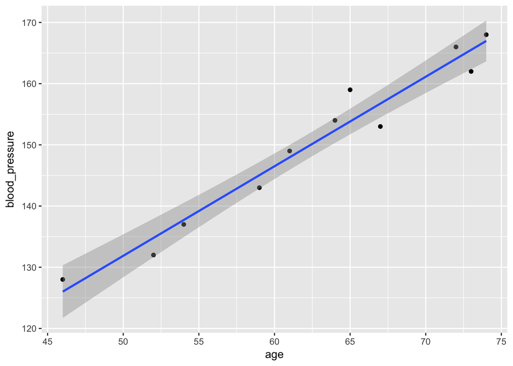

```r
# Visualization

ggplot(bloodpressure_isi,aes(age,blood_pressure)) + geom_point() + geom_smooth(method = "lm")
```

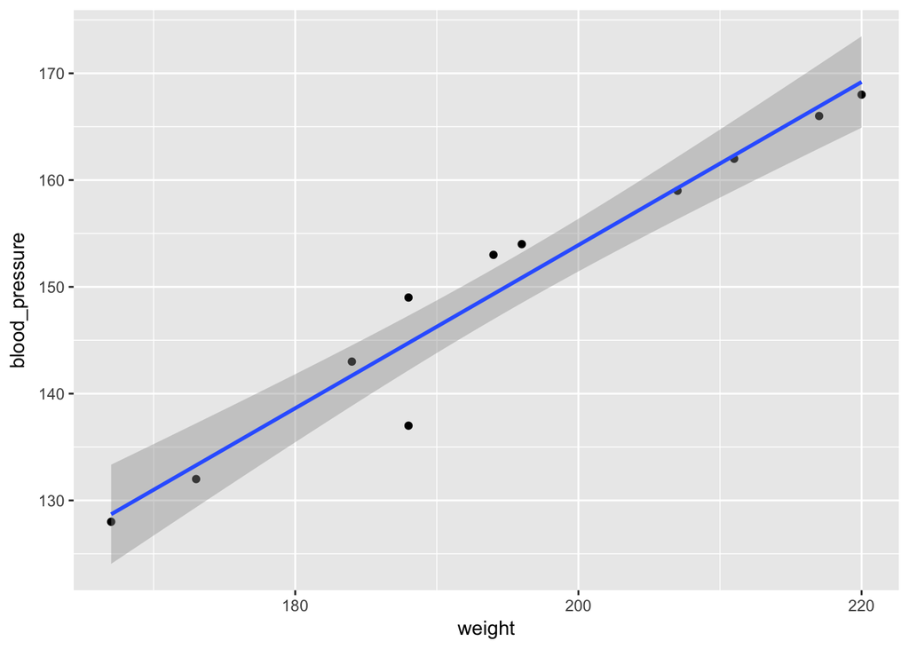

```r
ggplot(bloodpressure_isi,aes(weight,blood_pressure)) + geom_point() + geom_smooth(method = "lm")
```

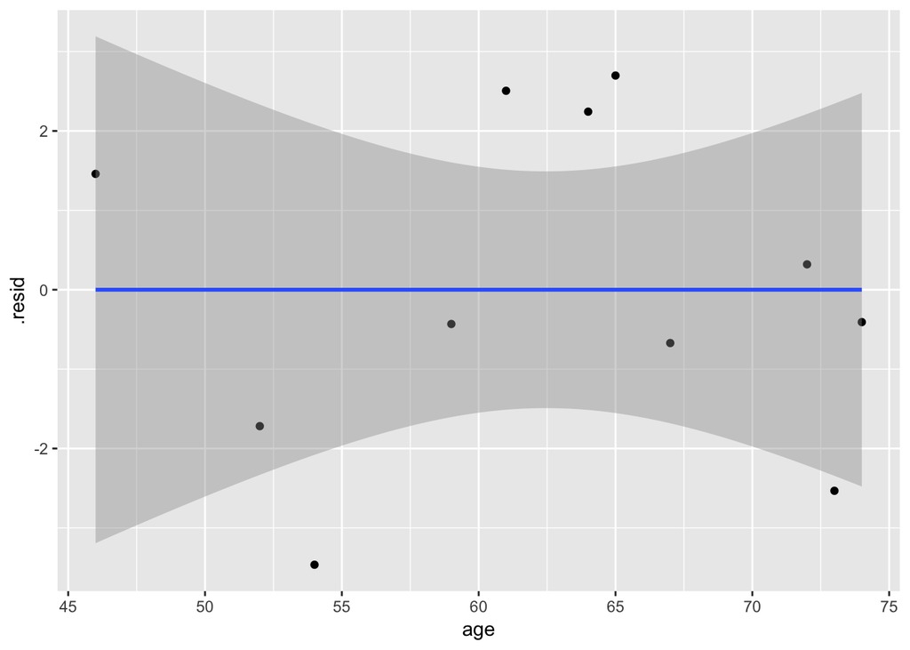

```r
# Residual analysis

ggplot(bloodpressure_aug,aes(age,.resid)) + geom_point() + geom_smooth(method = "lm")
```

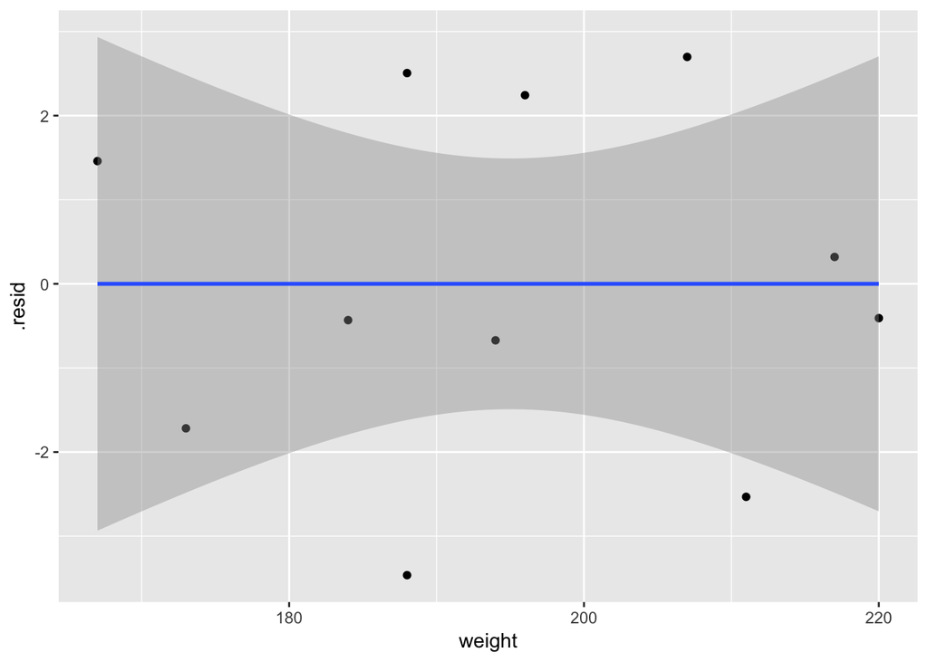

```r
ggplot(bloodpressure_aug,aes(weight,.resid)) + geom_point() + geom_smooth(method = "lm")
```

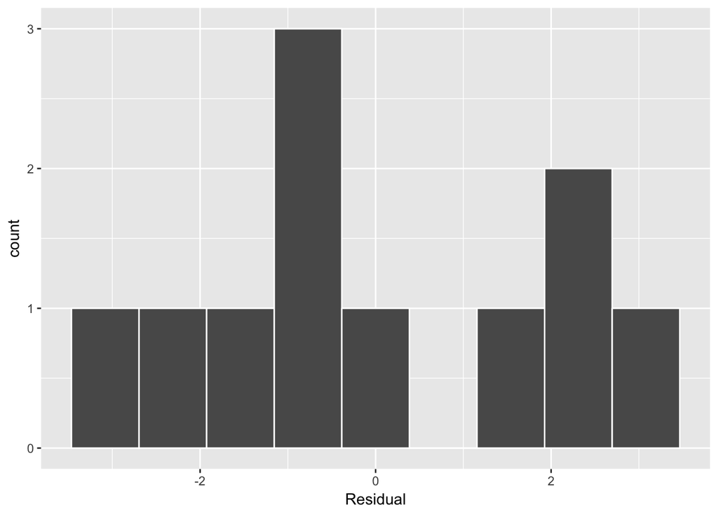

```r
ggplot(bloodpressure_aug, aes(x = .resid)) +geom_histogram(color = "white", bins = 9) + labs(x = "Residual")
```

> The Bloodpressure of a person appears to be highly significant. The $R^2$ suggests that the model explains 97% of the variability of the response variable ‘blood pressure’

> .

$$bloodpressure= 30.99 + 0.86 * age + 0.33 * weight$$

### CASE 3 : Build a multiple linear regression on Sparrow bird data

```r
# Fitting a model

sparrow_lm <-  lm(total_length ~ wingspan + weight,data=sparrow_isi)


# Summarizing a model

knitr::kable(sparrow_lm %>% tidy())
```

| term | estimate | std.error | statistic | p.value |
| --- | --- | --- | --- | --- |
| (Intercept) | 58.0127939 | 14.8155167 | 3.915678 | 0.0001827 |
| wingspan | 0.3466034 | 0.0677148 | 5.118579 | 0.0000019 |
| weight | 0.6448308 | 0.2107399 | 3.059842 | 0.0029722 |

```r
sparrow_aug1 <- sparrow_lm %>% augment()

knitr::kable(head(sparrow_aug1))
```

| total_length | wingspan | weight | .fitted | .se.fit | .resid | .hat | .sigma | .cooksd | .std.resid |
| --- | --- | --- | --- | --- | --- | --- | --- | --- | --- |
| 154 | 241 | 24.5 | 157.3426 | 0.4626258 | -3.342563 | 0.0368729 | 2.394680 | 0.0255051 | -1.4137149 |
| 160 | 252 | 26.9 | 162.7028 | 0.3787694 | -2.702794 | 0.0247171 | 2.404998 | 0.0109016 | -1.1359826 |
| 155 | 243 | 26.9 | 159.5834 | 0.5308544 | -4.583363 | 0.0485511 | 2.368173 | 0.0647029 | -1.9503638 |
| 154 | 245 | 24.3 | 158.6000 | 0.3769255 | -4.600010 | 0.0244771 | 2.369161 | 0.0312557 | -1.9331435 |
| 156 | 247 | 24.1 | 159.1643 | 0.4301215 | -3.164251 | 0.0318735 | 2.397844 | 0.0195540 | -1.3348391 |
| 161 | 253 | 26.5 | 162.7915 | 0.4165958 | -1.791465 | 0.0299005 | 2.415450 | 0.0058558 | -0.7549605 |

```r
knitr::kable(glance(sparrow_lm))
```

| r.squared | adj.r.squared | sigma | statistic | p.value | df | logLik | AIC | BIC | deviance | df.residual |
| --- | --- | --- | --- | --- | --- | --- | --- | --- | --- | --- |
| 0.4479982 | 0.4348553 | 2.409217 | 34.08671 | 0 | 3 | -198.4204 | 404.8409 | 414.7045 | 487.5635 | 84 |

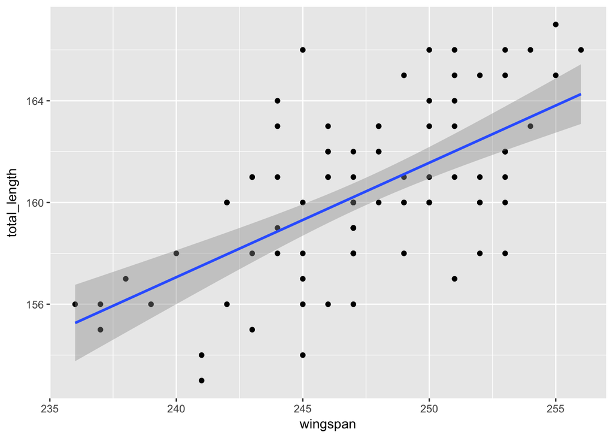

```r
# Visualization

ggplot(sparrow_isi,aes(wingspan,total_length)) + geom_point() + geom_smooth(method = "lm")
```

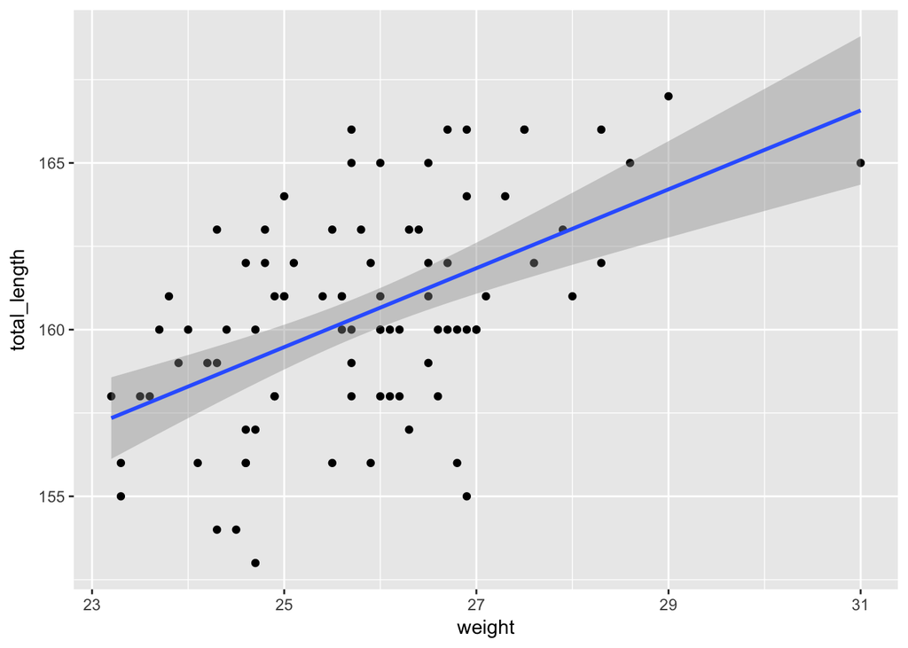

```r
ggplot(sparrow_isi,aes(weight,total_length)) + geom_point() + geom_smooth(method = "lm")
```

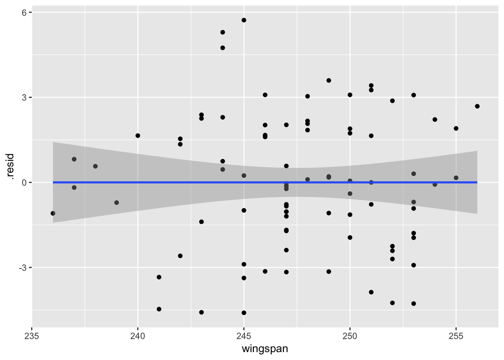

```r
# Residual Analysis

ggplot(sparrow_aug1,aes(wingspan,.resid)) + geom_point() + geom_smooth(method = "lm")
```

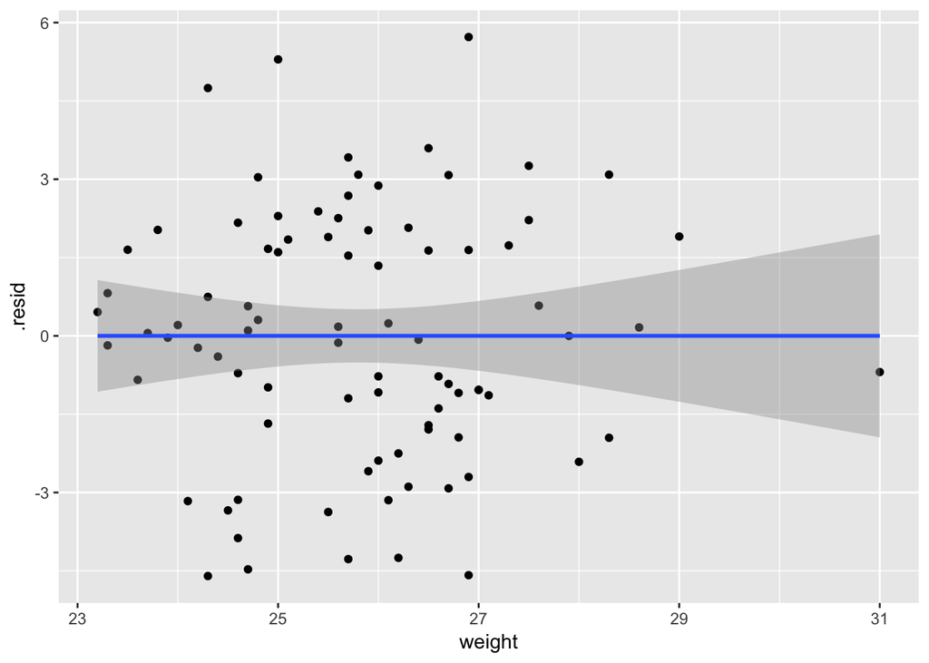

```r
ggplot(sparrow_aug1,aes(weight,.resid)) + geom_point() + geom_smooth(method = "lm")
```

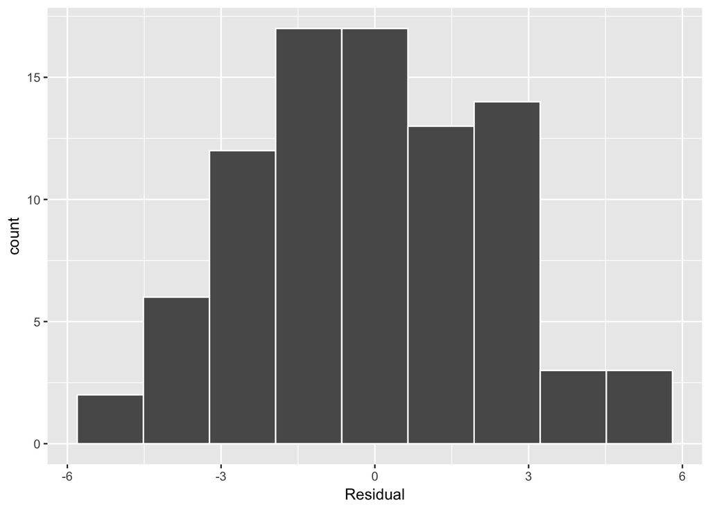

```r
ggplot(sparrow_aug1, aes(x = .resid)) +geom_histogram(color = "white", bins = 9) + labs(x = "Residual")
```

> .

$$totallength= 58.01 + 0.34 * wingspan + 0.64 * weight$$

> From the equation we can say that there is an expected increase of 0.34 percent of total length of a bird when its wingspan length gets increased a unit, and it will also be increased at 0.64 when its weigh up a unit

### CASE 4 : Build a multiple linear regression on Sparrow bird data

```r
# Data Manipulation
sparrow_age_adult <- sparrow_isi %>% filter(age=="adult")

sparrow_age_juv <- sparrow_isi %>% filter(age!="adult")

# Fitting a model

sparrow_adult_lm <-  lm(total_length ~ wingspan + weight,data=sparrow_age_adult)

sparrow_juv_lm <- lm(total_length ~ wingspan + weight,data=sparrow_age_juv)

# Summarizing model

knitr::kable(sparrow_adult_lm %>% tidy())
```

| term | estimate | std.error | statistic | p.value |
| --- | --- | --- | --- | --- |
| (Intercept) | 64.6420805 | 22.2184072 | 2.909393 | 0.0051856 |
| wingspan | 0.3189411 | 0.0982345 | 3.246732 | 0.0019738 |
| weight | 0.6456824 | 0.2602745 | 2.480775 | 0.0161403 |

```r
knitr::kable(sparrow_juv_lm %>% tidy())
```

| term | estimate | std.error | statistic | p.value |
| --- | --- | --- | --- | --- |
| (Intercept) | 51.3480435 | 19.7589762 | 2.598720 | 0.0154704 |
| wingspan | 0.3769424 | 0.0965953 | 3.902283 | 0.0006365 |
| weight | 0.6284490 | 0.3680396 | 1.707558 | 0.1001097 |

```r
sparrow_adult_aug <- sparrow_adult_lm %>% augment()

sparrow_juv_aug <- sparrow_juv_lm %>% augment()


knitr::kable(head(sparrow_adult_aug))
```

| total_length | wingspan | weight | .fitted | .se.fit | .resid | .hat | .sigma | .cooksd | .std.resid |
| --- | --- | --- | --- | --- | --- | --- | --- | --- | --- |
| 154 | 241 | 24.5 | 157.3261 | 0.6655335 | -3.326096 | 0.0720032 | 2.459003 | 0.0501209 | -1.3920908 |
| 160 | 252 | 26.9 | 162.3841 | 0.5171557 | -2.384086 | 0.0434765 | 2.481009 | 0.0146352 | -0.9828337 |
| 155 | 243 | 26.9 | 159.5136 | 0.7073639 | -4.513616 | 0.0813388 | 2.420793 | 0.1063964 | -1.8986850 |
| 154 | 245 | 24.3 | 158.4727 | 0.4829377 | -4.472724 | 0.0379135 | 2.425980 | 0.0444018 | -1.8385313 |
| 156 | 247 | 24.1 | 158.9815 | 0.5297850 | -2.981470 | 0.0456259 | 2.468623 | 0.0241282 | -1.2304871 |
| 161 | 253 | 26.5 | 162.4448 | 0.5811459 | -1.444754 | 0.0549013 | 2.494652 | 0.0069519 | -0.5991854 |

```r
knitr::kable(head(sparrow_juv_aug))
```

| total_length | wingspan | weight | .fitted | .se.fit | .resid | .hat | .sigma | .cooksd | .std.resid |
| --- | --- | --- | --- | --- | --- | --- | --- | --- | --- |
| 156 | 246 | 24.6 | 159.5357 | 0.5850995 | -3.5357130 | 0.0635500 | 2.248374 | 0.0560576 | -1.5742099 |
| 156 | 245 | 25.5 | 159.7244 | 0.4733150 | -3.7243747 | 0.0415869 | 2.237942 | 0.0388591 | -1.6390981 |
| 163 | 248 | 24.8 | 160.4153 | 0.6068818 | 2.5847125 | 0.0683698 | 2.304914 | 0.0325639 | 1.1537677 |
| 163 | 248 | 26.3 | 161.3580 | 0.4626458 | 1.6420390 | 0.0397332 | 2.344019 | 0.0071890 | 0.7219638 |
| 160 | 250 | 24.4 | 160.9178 | 0.8346107 | -0.9177927 | 0.1293075 | 2.360320 | 0.0088903 | -0.4237797 |
| 156 | 237 | 23.3 | 155.3262 | 0.9697621 | 0.6737521 | 0.1745767 | 2.364002 | 0.0071973 | 0.3195139 |

```r
knitr::kable(glance(sparrow_adult_lm))
```

| r.squared | adj.r.squared | sigma | statistic | p.value | df | logLik | AIC | BIC | deviance | df.residual |
| --- | --- | --- | --- | --- | --- | --- | --- | --- | --- | --- |
| 0.3440624 | 0.3206361 | 2.480242 | 14.68699 | 7.4e-06 | 3 | -135.7709 | 279.5418 | 287.8519 | 344.4895 | 56 |

```r
knitr::kable(glance(sparrow_juv_lm))
```

| r.squared | adj.r.squared | sigma | statistic | p.value | df | logLik | AIC | BIC | deviance | df.residual |
| --- | --- | --- | --- | --- | --- | --- | --- | --- | --- | --- |
| 0.6181779 | 0.5876321 | 2.320984 | 20.23776 | 5.9e-06 | 3 | -61.71943 | 131.4389 | 136.7677 | 134.6741 | 25 |

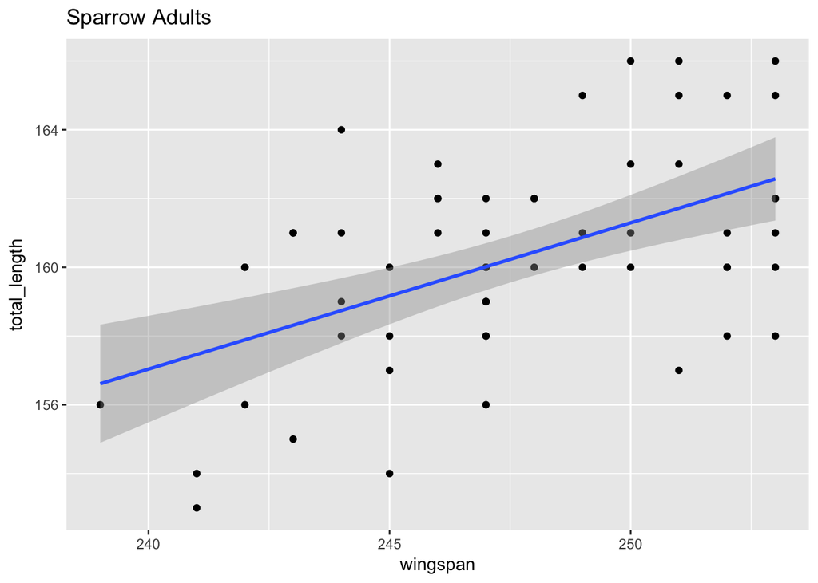

```r
ggplot(sparrow_age_adult,aes(wingspan,total_length)) + geom_point() + geom_smooth(method = "lm")  + labs(title="Sparrow Adults")
```

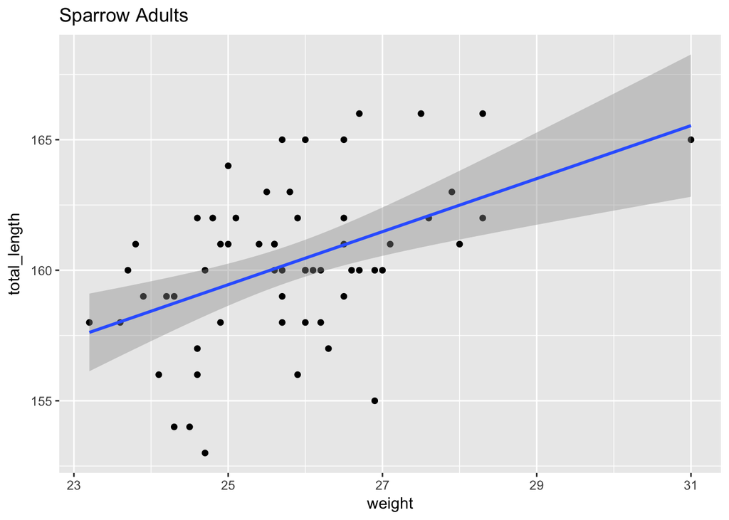

```r
ggplot(sparrow_age_adult,aes(weight,total_length)) + geom_point() + geom_smooth(method = "lm") + labs(title="Sparrow Adults")
```

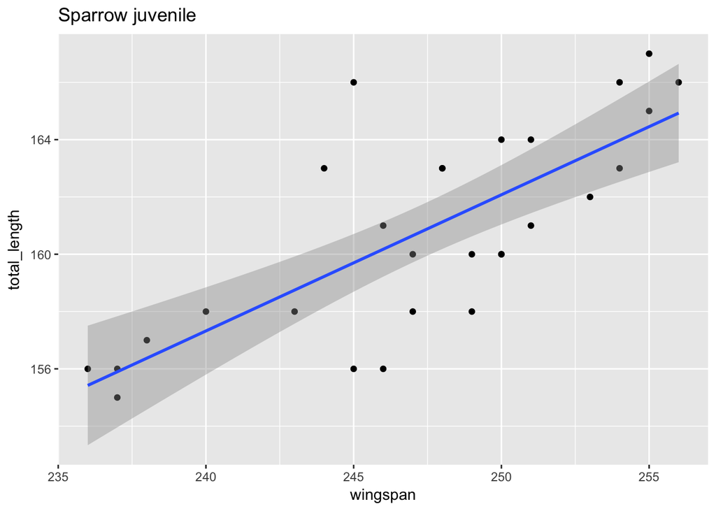

```r
ggplot(sparrow_age_juv,aes(wingspan,total_length)) + geom_point() + geom_smooth(method = "lm") + labs(title="Sparrow juvenile")
```

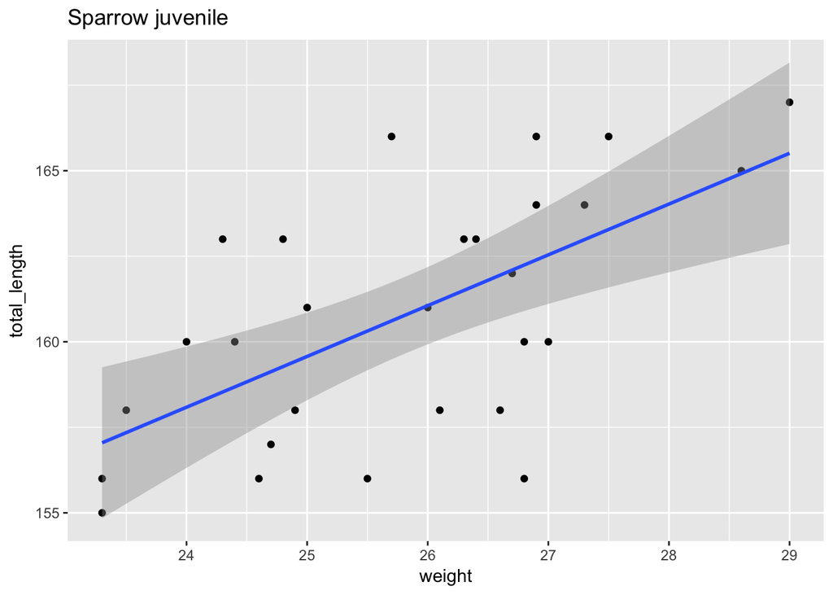

```r
ggplot(sparrow_age_juv,aes(weight,total_length)) + geom_point() + geom_smooth(method = "lm") + labs(title="Sparrow juvenile")
```

> .

> .

$$totallength= 64.64 + 0.31 * wingspan + 0.64 * weight$$

$$totallength= 51.34 + 0.37 * wingspan + 0.62 * weight$$

> From the equation we can say that there is an expected increase of 0.31 percent of total length of an adult bird when its wingspan length gets increased a unit, and it will also be increased at 0.64 when its weigh up a unit

### CASE 5: Build a simple linear regression on Runners data

```r
# Fitting a model

runners_isi <- na.omit(runners_isi)

runners_lm <- lm(net ~ gun, data=runners_isi)

#runners_lm_on <- lm(gun ~ age, data = runners_isi)

# Summarizing model

knitr::kable(runners_lm %>% tidy())
```

| term | estimate | std.error | statistic | p.value |
| --- | --- | --- | --- | --- |
| (Intercept) | 5.695583 | 0.1550411 | 36.73595 | 0 |
| gun | 0.906228 | 0.0016691 | 542.93880 | 0 |

```r
#knitr::kable(runners_lm_on %>% tidy())

runners_aug1 <- runners_lm %>% augment()

#runners_aug2 <- runners_lm_on %>% augment()

knitr::kable(head(runners_aug1))
```

| net | gun | .fitted | .se.fit | .resid | .hat | .sigma | .cooksd | .std.resid |
| --- | --- | --- | --- | --- | --- | --- | --- | --- |
| 82.37 | 85.70 | 83.35933 | 0.0295026 | -0.9893264 | 0.0002571 | 1.840090 | 0.0000372 | -0.5377644 |
| 69.32 | 69.68 | 68.84155 | 0.0457299 | 0.4784469 | 0.0006177 | 1.840137 | 0.0000209 | 0.2601145 |
| 79.70 | 80.42 | 78.57444 | 0.0333884 | 1.1255577 | 0.0003293 | 1.840072 | 0.0000617 | 0.6118372 |
| 111.80 | 121.20 | 115.53042 | 0.0571007 | -3.7304220 | 0.0009631 | 1.839277 | 0.0019833 | -2.0284477 |
| 104.20 | 104.20 | 100.12455 | 0.0352102 | 4.0754548 | 0.0003662 | 1.839109 | 0.0008990 | 2.2154003 |
| 76.57 | 76.88 | 75.36639 | 0.0369543 | 1.2036050 | 0.0004034 | 1.840060 | 0.0000864 | 0.6542868 |

```r
#knitr::kable(head(runners_aug2))


knitr::kable(glance(runners_lm))
```

| r.squared | adj.r.squared | sigma | statistic | p.value | df | logLik | AIC | BIC | deviance | df.residual |
| --- | --- | --- | --- | --- | --- | --- | --- | --- | --- | --- |
| 0.985514 | 0.9855106 | 1.839939 | 294782.5 | 0 | 2 | -8793.288 | 17592.58 | 17611.7 | 14668.83 | 4333 |

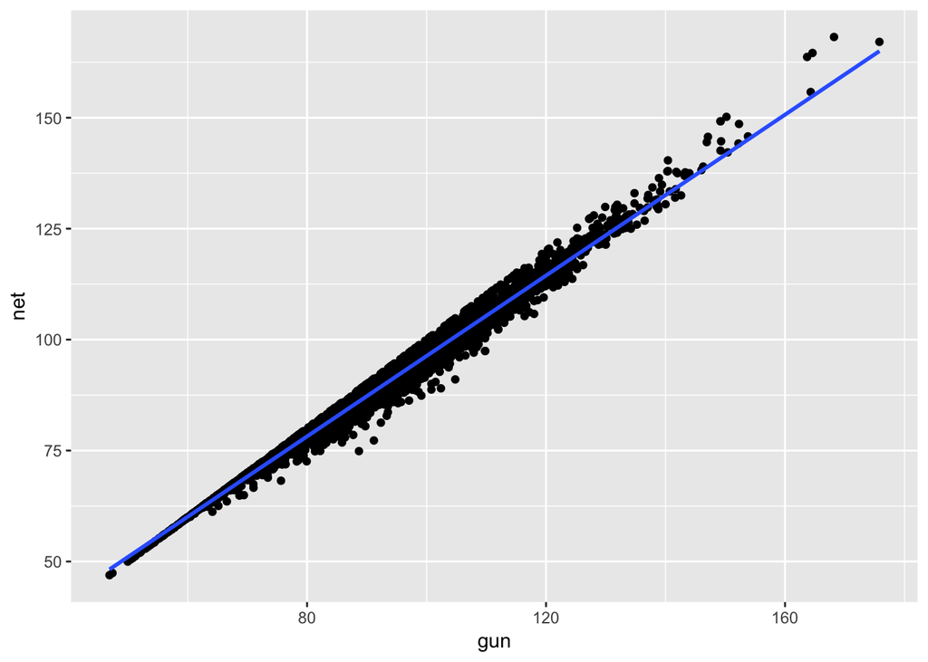

```r
#knitr::kable(glance(runners_lm_on))


# Visualizing model

ggplot(runners_isi,aes(gun,net)) + geom_point() + geom_smooth(method = "lm")
```

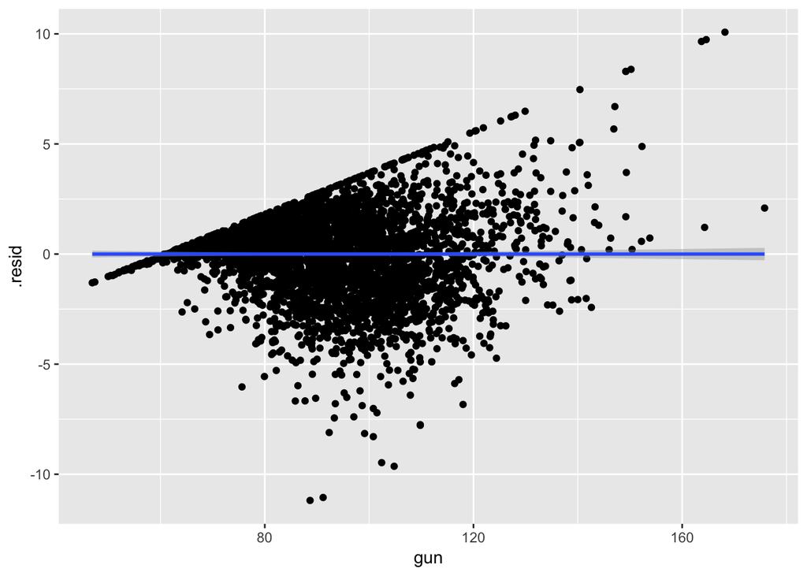

```r
#ggplot(runners_isi,aes(age,gun)) + geom_point() + geom_smooth(method = "lm")


# Residual analysis


ggplot(runners_aug1,aes(gun,.resid)) + geom_point() + geom_smooth(method = "lm")
```

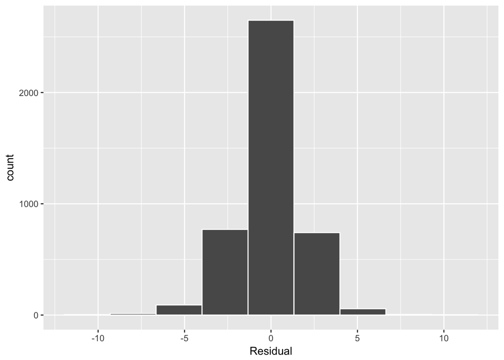

```r
#ggplot(runners_aug2,aes(age,.resid)) + geom_point() + geom_smooth(method = "lm")

ggplot(runners_aug1, aes(x = .resid)) +geom_histogram(color = "white", bins = 9) + labs(x = "Residual")
```

```r
#ggplot(runners_aug2, aes(x = .resid)) +geom_histogram(color = "white", bins = 9) + labs(x = "Residual")
```

> The net rate of a runner looks to be higly significant.The $R^2$ suggests that the model explains 98% of the variability of the response variable ‘net’ running rate of a player

> .

$$net= 5.69 + 0.90 * gun$$

> From the equation we can say that there is an expected increase of 0.90 percent of runner net rate of a player if his gun rate go up a unit

```r
# Split data into training and testing sets
set.seed(1234)
runners_train <- createDataPartition(as.factor(runners_isi$runs_again),
                                p = 0.7, list = FALSE)

training_runners <- runners_isi[runners_train, ]
testing_runners <- runners_isi[-runners_train, ]


# Fitting a model

#runners_glm <- glm(as.factor(runs_again) ~ age + gun , data=training_runners,family = "binomial")

runners_glm <- train(as.factor(runs_again) ~ age + gun, method = "glm", family = "binomial",
                   data = training_runners,
                   trControl = trainControl(method = "none"))
```

```r
# Confusion matrix for logistic regression model on training data
confusionMatrix(predict(runners_glm, training_runners), training_runners$runs_again)
```

```
## Confusion Matrix and Statistics
##
##           Reference
## Prediction FALSE TRUE
##      FALSE   127   95
##      TRUE   1024 1789
##
##                Accuracy : 0.6313
##                  95% CI : (0.6139, 0.6485)
##     No Information Rate : 0.6208
##     P-Value [Acc > NIR] : 0.1192
##
##                   Kappa : 0.0711
##  Mcnemar's Test P-Value : <2e-16
##
##             Sensitivity : 0.11034
##             Specificity : 0.94958
##          Pos Pred Value : 0.57207
##          Neg Pred Value : 0.63598
##              Prevalence : 0.37924
##          Detection Rate : 0.04185
##    Detection Prevalence : 0.07315
##       Balanced Accuracy : 0.52996
##
##        'Positive' Class : FALSE
##
```

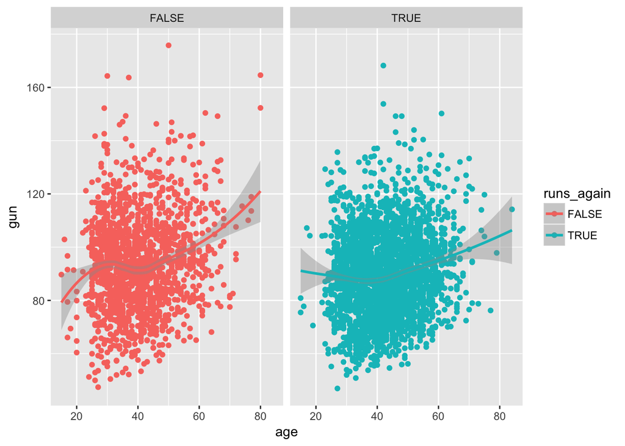

```r
# Visualization

ggplot(runners_isi,aes(age,gun,col=runs_again)) + geom_point() + geom_smooth(method = "loess") + facet_wrap(~runs_again)
```

## Statistical learning/Modeling

Data modeling is used in a wide variety of fields, including statistical inference, causal inference, artificial intelligence, and machine learning. There are many techniques for data modeling, such as tree-based models, neural networks/deep learning, and more

Here linear regression id one of the most commonly-used and easy-to-understand approaches to modeling

*data modeling can be used for two purposes:*

*Modeling for prediction:*

We want to predict an outcome variable *y* based on the information contained in a set of predictor variables. We don’t care so much about understanding how all the variables relate and interact, but so long as we can make good predictions about Y we’re fine. For example, if we know many individuals’ risk factors for lung cancer, such as smoking habits and age, can we predict whether or not they will develop lung cancer? Here we wouldn’t care so much about distinguishing the degree to which the different risk factors contribute to lung cancer, but instead only on whether or not they could be put together to make reliable predictions.

*Modeling for explanation:*

We want to explicitly describe the relationship between an outcome variable y and a set of explanatory variables, determine the significance of any found relationships, and have measures summarizing these. Continuing our example from above, we would now be interested in describing the individual effects of the different risk factors and quantifying the magnitude of these effects. One reason could be to design an intervention to reduce lung cancer cases in a population, such as targeting smokers of a specific age group with an advertisement for smoking cessation programs. In this book, we’ll focus more on this latter purpose.

Types of regression analyis

- Simple linear :

  Predicting a quantitative response variable from a quantitative explanatory variable
- Multiple linear :

  Predicting a quantitative response variable from two or more explonatory variables
- Logistic :

  Predicting a categorical response variable from one or more explonatory variables
- Poission :

  Predicting a response variable representing counts from one or more explanatory variables
- Multivariate :

  Predicting more than one response variable from one or more explonatory variables